# Testing affect regulation via computational modeling of real-time alcohol choices in daily life — Sensitivity Analyses: Drift Rate

### 4.3.4 Predicted vs. Observed

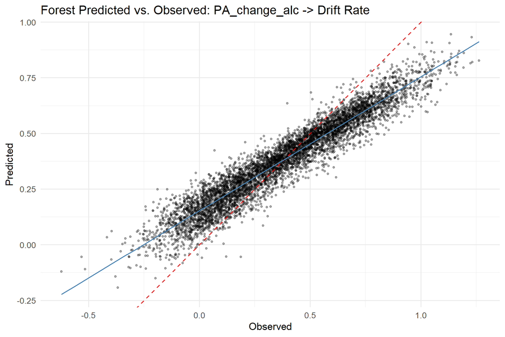

## 4.4 Model Comparison

### 4.4.1 RMSE Comparison (all methods and feature sets)

| Method | Raw | PCA | UMAP |
| --- | --- | --- | --- |
| glmm | 0.3059 | 0.3067 | 0.3036 |
| forest | 0.2522 | 0.2833 | 0.2691 |
| tree | 0.3014 | 0.3019 | 0.3014 |

# 5 Perceived Stress Change (vs. last assessment) (stress_state_change)

## 5.1 Dimensionality Reduction

- **PCA components (80% variance, max 5):** 5
- **UMAP components (matching PCA):** 5

### 5.1.1 PCA Component Composition (top 5 correlated variables)

**PC_1**

| Variable | Correlation |
| --- | --- |
| alc_exp_energeticYes | -0.576 |
| alc_exp_better_moodYes | -0.557 |
| alc_exp_sociableYes | -0.547 |
| alc_exp_buzzYes | -0.502 |
| alc_craving | -0.487 |

**PC_2**

| Variable | Correlation |
| --- | --- |
| alc_exp_injuryYes | -0.596 |
| alc_exp_be_rudeYes | -0.594 |
| alc_exp_embarrassedYes | -0.579 |
| alc_exp_nauseous_vomitYes | -0.491 |
| alc_exp_hangoverYes | -0.468 |

**PC_3**

| Variable | Correlation |
| --- | --- |
| locationschool_work | 0.591 |
| alc_today | -0.579 |
| alc_cuenone | 0.569 |
| time_of_dayevening | -0.476 |
| locationhome | -0.458 |

**PC_4**

| Variable | Correlation |
| --- | --- |
| soft_yday | 0.699 |
| soft_today | 0.651 |
| soft_intend | 0.635 |
| soft_craving | 0.489 |
| alc_exp_embarrassedYes | -0.388 |

**PC_5**

| Variable | Correlation |
| --- | --- |
| locationhome | -0.633 |
| social_context_aloneYes | -0.559 |
| social_context_friend_roommateYes | 0.500 |
| social_context_strangerYes | 0.418 |
| locationsomeone_elses_home | 0.371 |

### 5.1.2 UMAP Component Composition (top 5 correlated variables)

**UMAP_1**

| Variable | Correlation |
| --- | --- |
| alc_yday | -0.376 |
| alc_intend | -0.269 |
| alc_exp_embarrassedYes | -0.212 |
| alc_exp_be_rudeYes | -0.210 |
| alc_craving | -0.200 |

**UMAP_2**

| Variable | Correlation |
| --- | --- |
| alc_exp_embarrassedYes | -0.247 |
| alc_exp_be_rudeYes | -0.243 |
| alc_yday | 0.230 |
| alc_mot_enhanceYes | 0.118 |
| responsibilityYes | 0.113 |

**UMAP_3**

| Variable | Correlation |
| --- | --- |
| alc_yday | -0.493 |
| alc_today | -0.449 |
| alc_cuenone | 0.201 |
| alc_intend | -0.187 |
| time_of_dayevening | -0.138 |

**UMAP_4**

| Variable | Correlation |
| --- | --- |
| soft_yday | 0.824 |
| soft_today | 0.743 |
| soft_intend | 0.590 |
| soft_craving | 0.331 |
| alc_exp_be_rudeYes | 0.140 |

**UMAP_5**

| Variable | Correlation |
| --- | --- |
| alc_exp_injuryYes | 0.500 |
| alc_exp_embarrassedYes | 0.373 |
| alc_exp_be_rudeYes | 0.371 |
| alc_exp_nauseous_vomitYes | 0.338 |
| alc_exp_energeticYes | 0.240 |

## 5.2 GLMM Results

### 5.2.1 Raw Features

- **Optimal lambda:** 0 (index 21 of 21)
- **CV RMSE:** 0.3113

**Non-zero coefficients** (focal predictor terms highlighted):

| Term | Estimate | Category |
| --- | --- | --- |
| (Intercept) | 0.3759 | Intercept |
| stress_state_change | 0.0030 | Focal predictor |
| alc_exp_injuryYes | -0.0545 | Covariate main effect |
| alc_exp_embarrassedYes | -0.0509 | Covariate main effect |
| alc_exp_be_rudeYes | -0.0446 | Covariate main effect |
| alc_exp_nauseous_vomitYes | -0.0356 | Covariate main effect |
| alc_exp_hangoverYes | -0.0308 | Covariate main effect |
| alc_exp_relaxedYes | 0.0245 | Covariate main effect |
| social_context_strangerYes | 0.0176 | Covariate main effect |
| alc_exp_better_moodYes | 0.0166 | Covariate main effect |
| locationother | 0.0160 | Covariate main effect |
| alc_cueindirectly_visible | -0.0147 | Covariate main effect |
| alc_cuenone | -0.0145 | Covariate main effect |
| alc_mot_enhanceYes | 0.0118 | Covariate main effect |
| alc_mot_copingYes | 0.0110 | Covariate main effect |
| locationrestaurant_cafe | -0.0107 | Covariate main effect |
| social_context_coworker_classmateYes | 0.0103 | Covariate main effect |
| alc_exp_buzzYes | 0.0089 | Covariate main effect |
| social_context_familyYes | -0.0081 | Covariate main effect |
| alc_exp_sociableYes | -0.0069 | Covariate main effect |
| soft_intend | -0.0066 | Covariate main effect |
| alc_craving | 0.0063 | Covariate main effect |
| responsibilityYes | -0.0062 | Covariate main effect |
| time_of_dayevening | -0.0060 | Covariate main effect |
| soft_today | -0.0057 | Covariate main effect |
| social_context_otherYes | 0.0057 | Covariate main effect |
| alc_intend | 0.0056 | Covariate main effect |
| social_context_romantic_partnerYes | 0.0056 | Covariate main effect |
| bored_state | 0.0042 | Covariate main effect |
| soft_yday | -0.0040 | Covariate main effect |

[output cut: 65 more lines]

- 3 coefficients penalized to zero.*

#### 5.2.1.1 Predicted vs. Observed

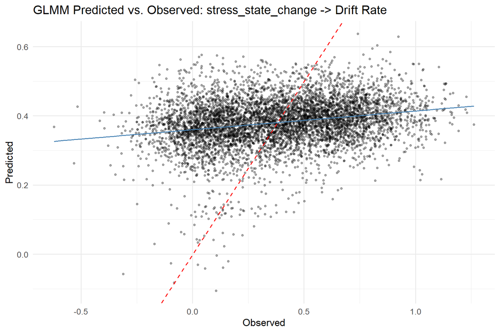

#### 5.2.1.2 Residual Diagnostics

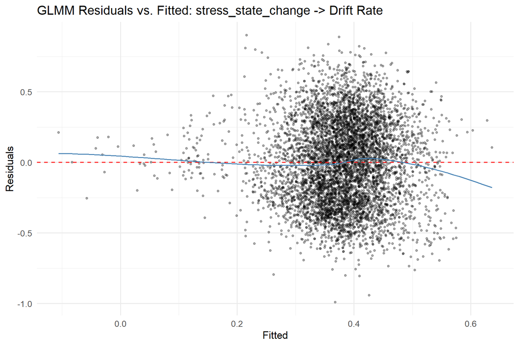

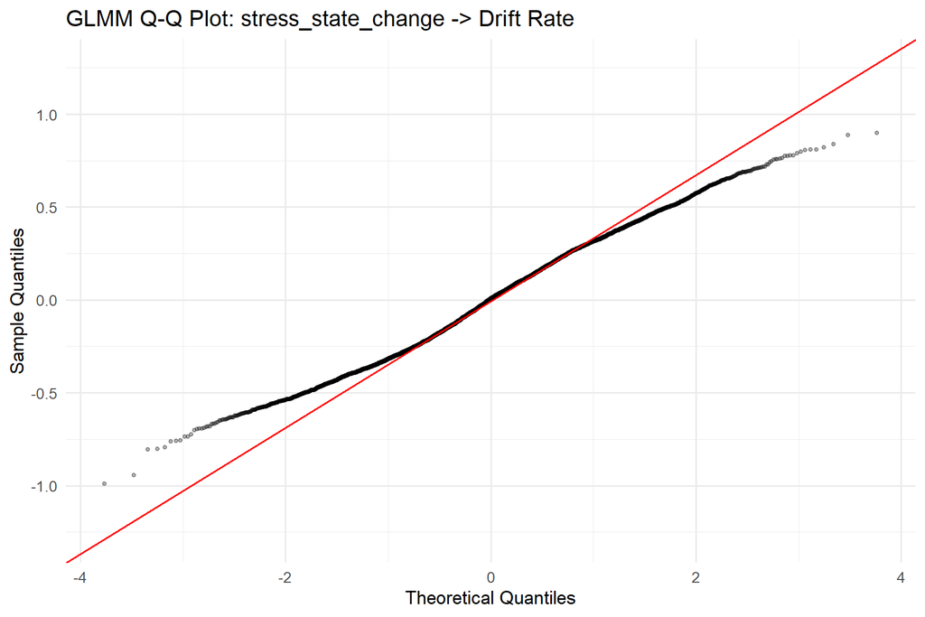

### 5.2.2 PCA Features

- **Optimal lambda:** 100 (index 1 of 21)
- **CV RMSE:** 0.3078

**Non-zero coefficients:**

| Term | Estimate |
| --- | --- |
| (Intercept) | 0.3820 |
| PC_2 | 0.0415 |
| PC_5:stress_state_change | 0.0092 |

- 9 coefficients penalized to zero.*

### 5.2.3 UMAP Features

- **Optimal lambda:** 100 (index 1 of 21)
- **CV RMSE:** 0.3041

**Non-zero coefficients:**

| Term | Estimate |
| --- | --- |
| (Intercept) | 0.3811 |
| UMAP_3 | -0.0132 |
| UMAP_4 | -0.0199 |
| UMAP_5:stress_state_change | 0.0025 |

- 8 coefficients penalized to zero.*

## 5.3 Random Forest Results (Raw)

### 5.3.1 Tuning Summary

- **mtry:** 15
- **min.node.size:** 4
- **sample.fraction:** 0.726
- **CV RMSE:** 0.2567

### 5.3.2 Variable Importance (Permutation)

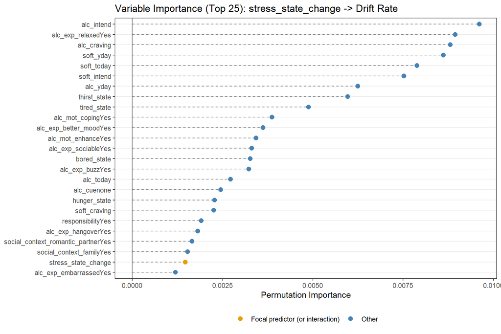

**Full importance ranking:**

| Variable | Importance |
| --- | --- |
| alc_intend | 0.009610 |
| alc_exp_relaxedYes | 0.008945 |
| alc_craving | 0.008806 |
| soft_yday | 0.008611 |
| soft_today | 0.007880 |
| soft_intend | 0.007522 |
| alc_yday | 0.006246 |
| thirst_state | 0.005965 |
| tired_state | 0.004877 |
| alc_mot_copingYes | 0.003872 |
| alc_exp_better_moodYes | 0.003619 |
| alc_mot_enhanceYes | 0.003425 |
| alc_exp_sociableYes | 0.003309 |
| bored_state | 0.003265 |
| alc_exp_buzzYes | 0.003223 |
| alc_today | 0.002721 |
| alc_cuenone | 0.002447 |
| hunger_state | 0.002278 |
| soft_craving | 0.002255 |
| responsibilityYes | 0.001912 |
| alc_exp_hangoverYes | 0.001817 |
| social_context_romantic_partnerYes | 0.001654 |
| social_context_familyYes | 0.001535 |
| stress_state_change | 0.001470 |
| alc_exp_embarrassedYes | 0.001193 |
| alc_exp_energeticYes | 0.001157 |
| social_context_aloneYes | 0.000965 |
| time_of_dayevening | 0.000879 |
| alc_exp_be_rudeYes | 0.000812 |
| locationhome | 0.000751 |
| alc_mot_socialYes | 0.000705 |
| locationschool_work | 0.000503 |
| locationother | 0.000404 |
| alc_exp_nauseous_vomitYes | 0.000382 |
| alc_exp_injuryYes | 0.000258 |
| social_context_coworker_classmateYes | 0.000223 |
| alc_cueindirectly_visible | 0.000218 |
| social_context_friend_roommateYes | 0.000198 |
| social_context_strangerYes | 0.000155 |
| locationsomeone_elses_home | 0.000069 |
| day_of_weekSat | 0.000029 |
| locationoutdoors | 0.000018 |
| day_of_weekSun | 0.000008 |
| social_context_otherYes | 0.000006 |
| locationrestaurant_cafe | -0.000006 |
| day_of_weekWed | -0.000072 |
| day_of_weekMon | -0.000081 |
| day_of_weekTue | -0.000172 |
| day_of_weekThu | -0.000176 |

### 5.3.3 Partial Dependence Plots

PDP for the focal predictor and the top 5 most important non-interaction covariates.

#### 5.3.3.1 Focal Predictor: stress_state_change

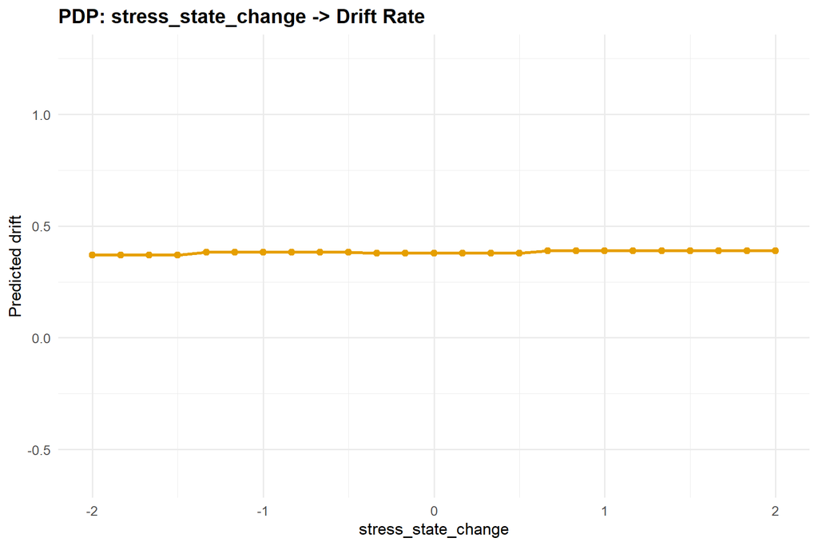

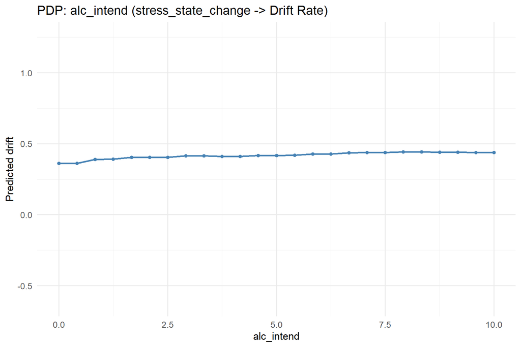

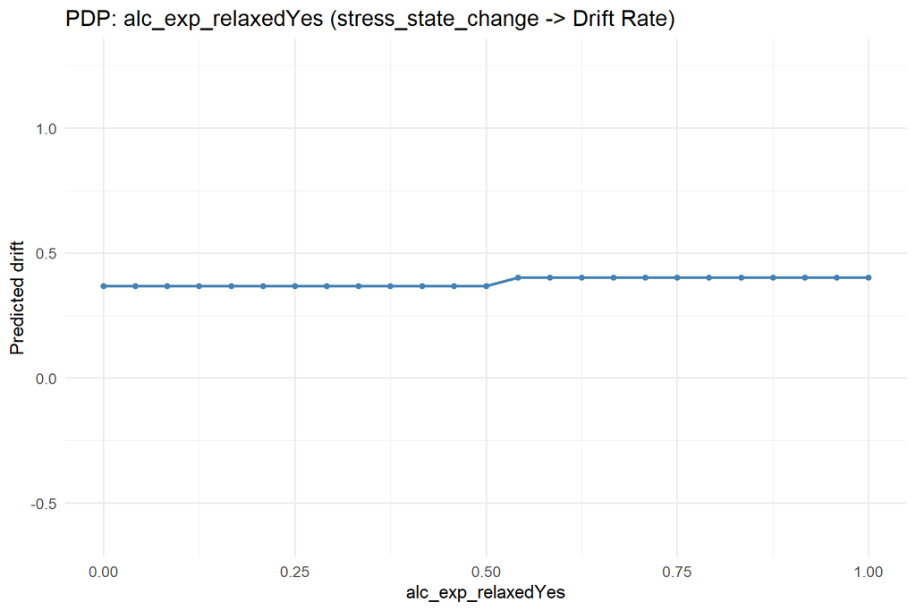

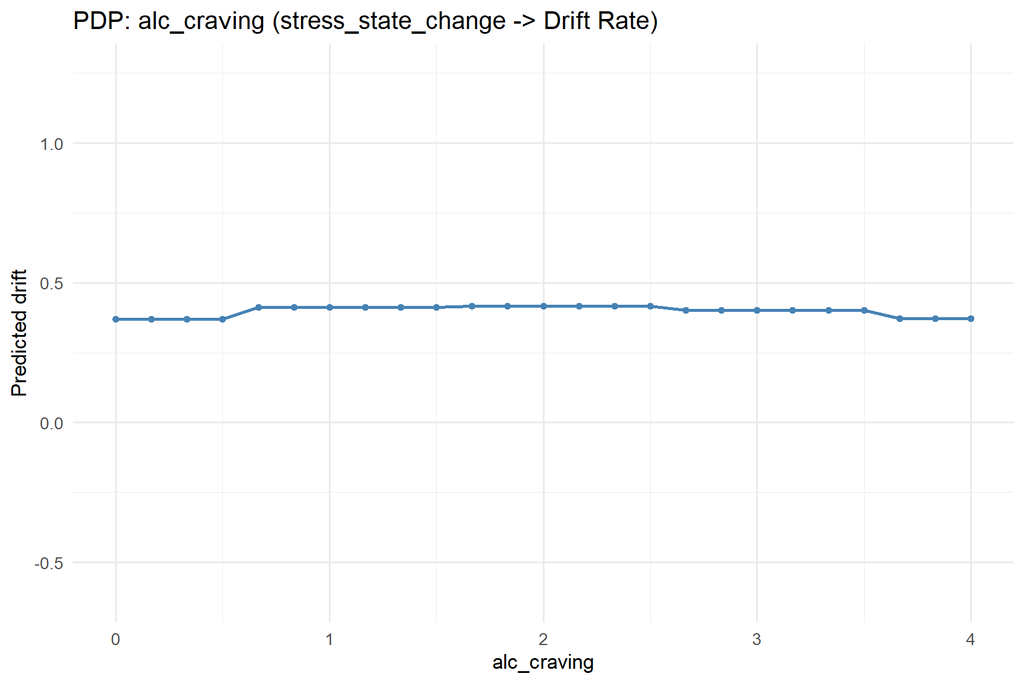

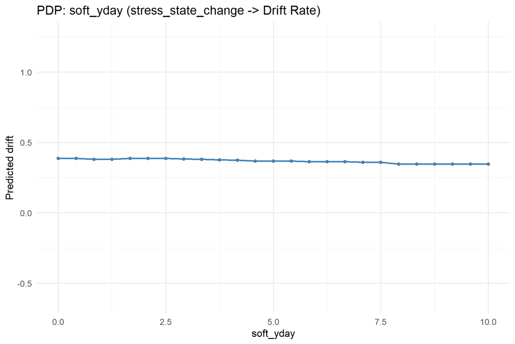

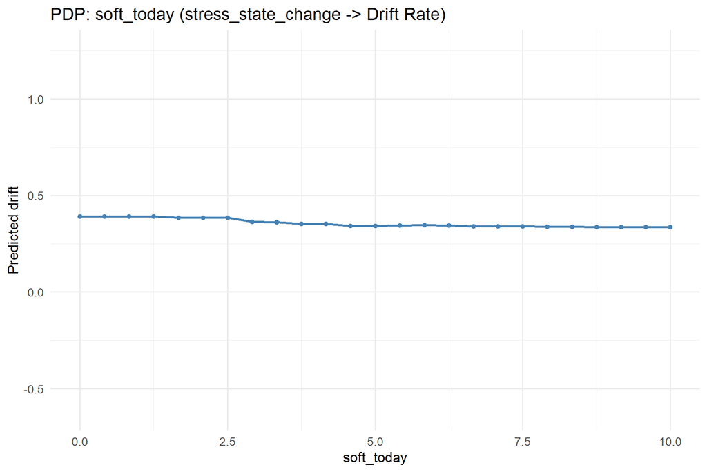

### 5.3.4 Predicted vs. Observed

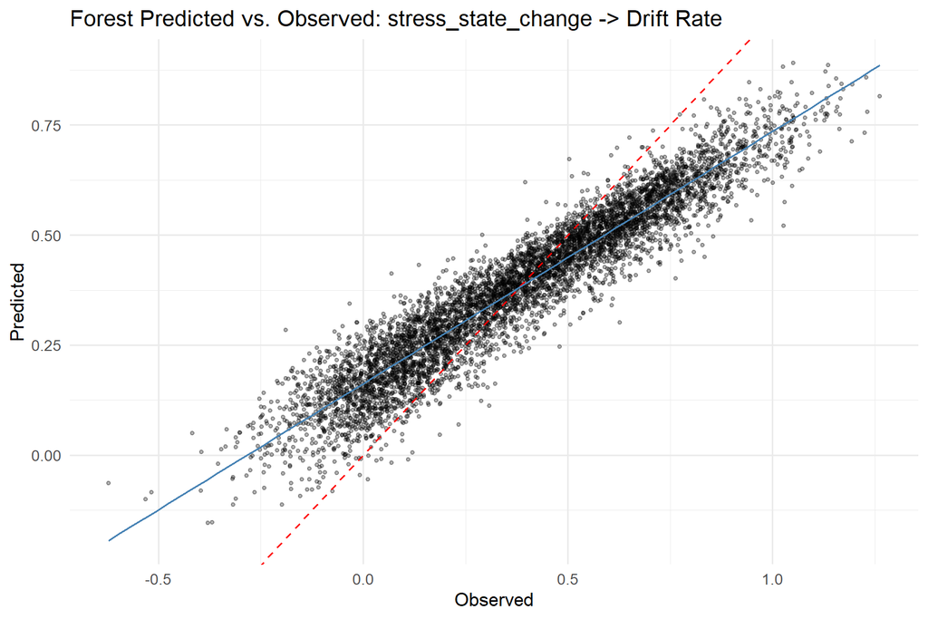

## 5.4 Model Comparison

### 5.4.1 RMSE Comparison (all methods and feature sets)

| Method | Raw | PCA | UMAP |
| --- | --- | --- | --- |
| glmm | 0.3113 | 0.3078 | 0.3041 |
| forest | 0.2567 | 0.2857 | 0.2725 |
| tree | 0.3016 | 0.3027 | 0.3046 |

# 6 Perceived Negative Affect Change (vs. last assessment) (NA_state_change)

## 6.1 Dimensionality Reduction

- **PCA components (80% variance, max 5):** 5
- **UMAP components (matching PCA):** 5

### 6.1.1 PCA Component Composition (top 5 correlated variables)

**PC_1**

| Variable | Correlation |
| --- | --- |
| alc_exp_energeticYes | -0.576 |
| alc_exp_better_moodYes | -0.557 |
| alc_exp_sociableYes | -0.547 |
| alc_exp_buzzYes | -0.503 |
| alc_craving | -0.487 |

**PC_2**

| Variable | Correlation |
| --- | --- |
| alc_exp_injuryYes | -0.596 |
| alc_exp_be_rudeYes | -0.594 |
| alc_exp_embarrassedYes | -0.579 |
| alc_exp_nauseous_vomitYes | -0.491 |
| alc_exp_hangoverYes | -0.468 |

**PC_3**

| Variable | Correlation |
| --- | --- |
| locationschool_work | 0.591 |
| alc_today | -0.578 |
| alc_cuenone | 0.569 |
| time_of_dayevening | -0.476 |
| locationhome | -0.458 |

**PC_4**

| Variable | Correlation |
| --- | --- |
| soft_yday | 0.699 |
| soft_today | 0.650 |
| soft_intend | 0.634 |
| soft_craving | 0.488 |
| alc_exp_embarrassedYes | -0.388 |

**PC_5**

| Variable | Correlation |
| --- | --- |
| locationhome | -0.632 |
| social_context_aloneYes | -0.560 |
| social_context_friend_roommateYes | 0.500 |
| social_context_strangerYes | 0.417 |
| locationsomeone_elses_home | 0.371 |

### 6.1.2 UMAP Component Composition (top 5 correlated variables)

**UMAP_1**

| Variable | Correlation |
| --- | --- |
| alc_exp_embarrassedYes | -0.283 |
| alc_exp_be_rudeYes | -0.279 |
| alc_craving | -0.187 |
| alc_yday | -0.172 |
| alc_intend | -0.146 |

**UMAP_2**

| Variable | Correlation |
| --- | --- |
| alc_yday | 0.283 |
| alc_exp_embarrassedYes | -0.128 |
| alc_exp_be_rudeYes | -0.124 |
| alc_intend | 0.113 |
| alc_mot_enhanceYes | 0.113 |

**UMAP_3**

| Variable | Correlation |
| --- | --- |
| alc_yday | 0.452 |
| alc_today | 0.440 |
| alc_intend | 0.223 |
| alc_cuenone | -0.204 |
| responsibilityYes | -0.134 |

**UMAP_4**

| Variable | Correlation |
| --- | --- |
| soft_yday | -0.797 |
| soft_today | -0.680 |
| soft_intend | -0.578 |
| soft_craving | -0.306 |
| alc_exp_injuryYes | -0.184 |

**UMAP_5**

| Variable | Correlation |
| --- | --- |
| alc_exp_injuryYes | -0.507 |
| alc_exp_embarrassedYes | -0.380 |
| alc_exp_be_rudeYes | -0.377 |
| alc_exp_nauseous_vomitYes | -0.350 |
| alc_exp_energeticYes | -0.235 |

## 6.2 GLMM Results

### 6.2.1 Raw Features

- **Optimal lambda:** 0 (index 21 of 21)
- **CV RMSE:** 0.3114

**Non-zero coefficients** (focal predictor terms highlighted):

| Term | Estimate | Category |
| --- | --- | --- |
| (Intercept) | 0.3750 | Intercept |
| NA_state_change | 0.0021 | Focal predictor |
| alc_exp_injuryYes | -0.0610 | Covariate main effect |
| alc_exp_embarrassedYes | -0.0565 | Covariate main effect |
| alc_exp_be_rudeYes | -0.0496 | Covariate main effect |
| alc_exp_nauseous_vomitYes | -0.0396 | Covariate main effect |
| alc_exp_hangoverYes | -0.0345 | Covariate main effect |
| alc_exp_relaxedYes | 0.0270 | Covariate main effect |
| social_context_strangerYes | 0.0205 | Covariate main effect |
| alc_exp_better_moodYes | 0.0185 | Covariate main effect |
| locationother | 0.0175 | Covariate main effect |
| alc_cueindirectly_visible | -0.0167 | Covariate main effect |
| alc_cuenone | -0.0166 | Covariate main effect |
| locationrestaurant_cafe | -0.0127 | Covariate main effect |
| alc_mot_enhanceYes | 0.0125 | Covariate main effect |
| alc_mot_copingYes | 0.0119 | Covariate main effect |
| social_context_coworker_classmateYes | 0.0116 | Covariate main effect |
| alc_exp_buzzYes | 0.0096 | Covariate main effect |
| social_context_otherYes | 0.0086 | Covariate main effect |
| social_context_familyYes | -0.0085 | Covariate main effect |
| alc_exp_sociableYes | -0.0077 | Covariate main effect |
| soft_intend | -0.0073 | Covariate main effect |
| alc_craving | 0.0071 | Covariate main effect |
| responsibilityYes | -0.0069 | Covariate main effect |
| time_of_dayevening | -0.0065 | Covariate main effect |
| soft_today | -0.0063 | Covariate main effect |
| alc_intend | 0.0062 | Covariate main effect |
| social_context_romantic_partnerYes | 0.0058 | Covariate main effect |
| soft_yday | -0.0046 | Covariate main effect |
| bored_state | 0.0045 | Covariate main effect |

[output cut: 67 more lines]

- 1 coefficients penalized to zero.*

#### 6.2.1.1 Predicted vs. Observed

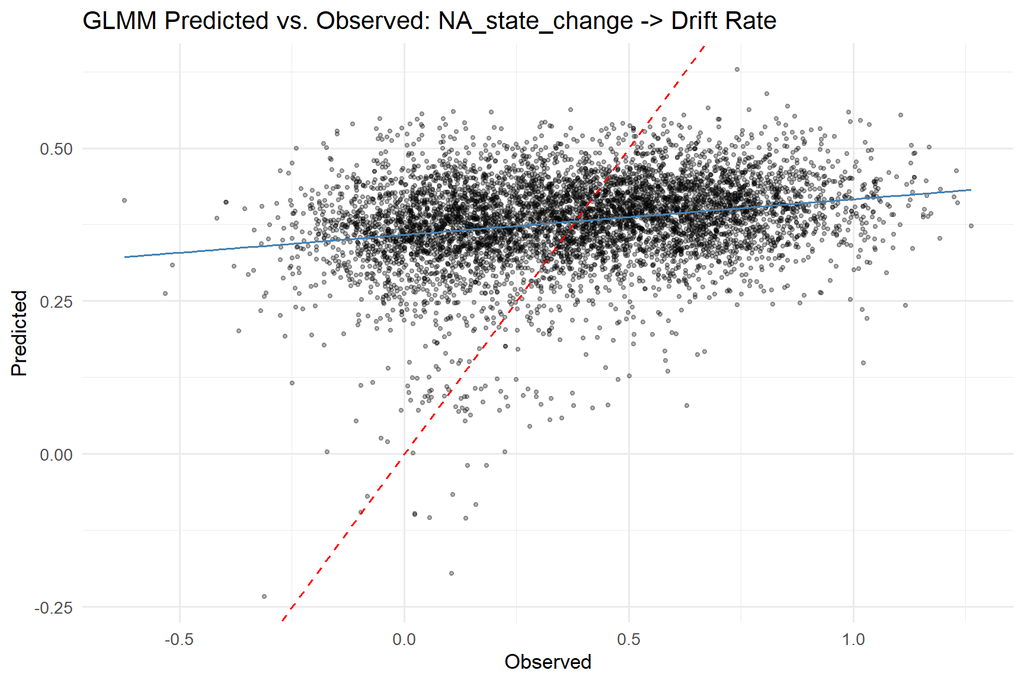

#### 6.2.1.2 Residual Diagnostics

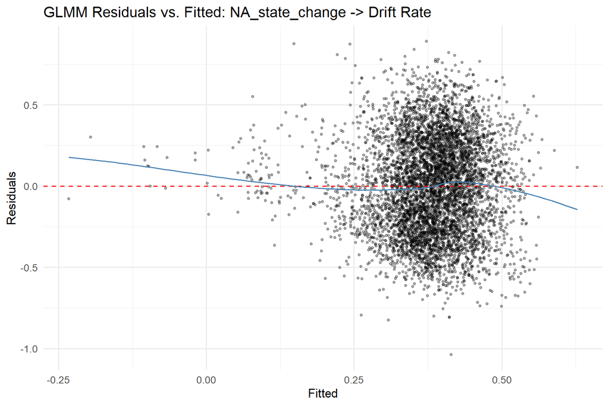

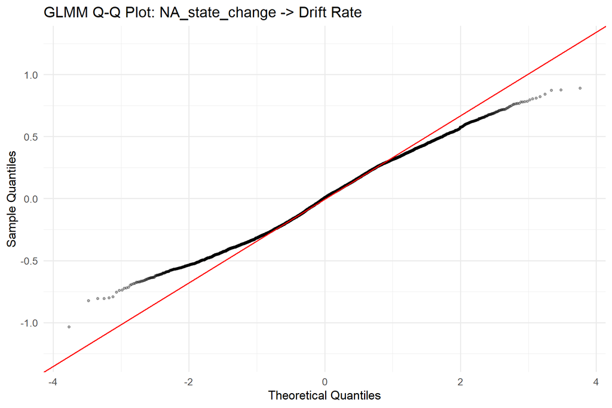

### 6.2.2 PCA Features

- **Optimal lambda:** 95 (index 2 of 21)
- **CV RMSE:** 0.3083

**Non-zero coefficients:**

| Term | Estimate |
| --- | --- |
| (Intercept) | 0.3814 |
| PC_2 | 0.0419 |
| PC_5:NA_state_change | 0.0039 |

- 9 coefficients penalized to zero.*

### 6.2.3 UMAP Features

- **Optimal lambda:** 85 (index 4 of 21)
- **CV RMSE:** 0.3132

**Non-zero coefficients:**

| Term | Estimate |
| --- | --- |
| (Intercept) | 0.3809 |
| UMAP_3 | 0.0034 |
| UMAP_5:NA_state_change | -0.0032 |

- 9 coefficients penalized to zero.*

## 6.3 Random Forest Results (Raw)

### 6.3.1 Tuning Summary

- **mtry:** 14
- **min.node.size:** 5
- **sample.fraction:** 0.79
- **CV RMSE:** 0.2564

### 6.3.2 Variable Importance (Permutation)

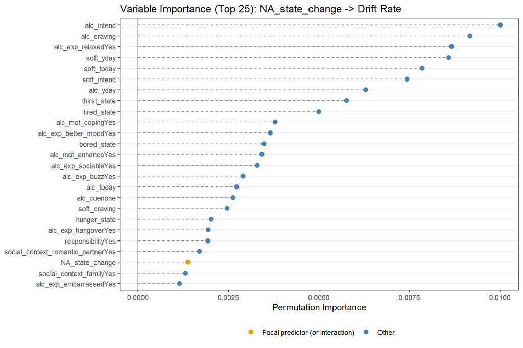

**Full importance ranking:**

| Variable | Importance |
| --- | --- |
| alc_intend | 0.010010 |
| alc_craving | 0.009172 |
| alc_exp_relaxedYes | 0.008663 |
| soft_yday | 0.008589 |
| soft_today | 0.007854 |
| soft_intend | 0.007425 |
| alc_yday | 0.006288 |
| thirst_state | 0.005764 |
| tired_state | 0.004988 |
| alc_mot_copingYes | 0.003788 |
| alc_exp_better_moodYes | 0.003652 |
| bored_state | 0.003479 |
| alc_mot_enhanceYes | 0.003416 |
| alc_exp_sociableYes | 0.003298 |
| alc_exp_buzzYes | 0.002903 |
| alc_today | 0.002724 |
| alc_cuenone | 0.002628 |
| soft_craving | 0.002455 |
| hunger_state | 0.002024 |
| alc_exp_hangoverYes | 0.001936 |
| responsibilityYes | 0.001934 |
| social_context_romantic_partnerYes | 0.001697 |
| NA_state_change | 0.001378 |
| social_context_familyYes | 0.001316 |
| alc_exp_embarrassedYes | 0.001147 |
| alc_exp_energeticYes | 0.001099 |
| social_context_aloneYes | 0.001027 |
| time_of_dayevening | 0.000867 |
| alc_exp_be_rudeYes | 0.000847 |
| locationhome | 0.000776 |
| alc_mot_socialYes | 0.000671 |
| locationschool_work | 0.000532 |
| alc_exp_nauseous_vomitYes | 0.000345 |
| locationother | 0.000345 |
| alc_exp_injuryYes | 0.000288 |
| social_context_coworker_classmateYes | 0.000247 |
| alc_cueindirectly_visible | 0.000244 |
| social_context_friend_roommateYes | 0.000233 |
| social_context_strangerYes | 0.000223 |
| day_of_weekSun | 0.000074 |
| locationoutdoors | 0.000063 |
| locationsomeone_elses_home | 0.000049 |
| locationrestaurant_cafe | 0.000024 |
| social_context_otherYes | 0.000011 |
| day_of_weekSat | -0.000018 |
| day_of_weekWed | -0.000110 |
| day_of_weekMon | -0.000137 |
| day_of_weekTue | -0.000200 |
| day_of_weekThu | -0.000251 |

### 6.3.3 Partial Dependence Plots

PDP for the focal predictor and the top 5 most important non-interaction covariates.

#### 6.3.3.1 Focal Predictor: NA_state_change

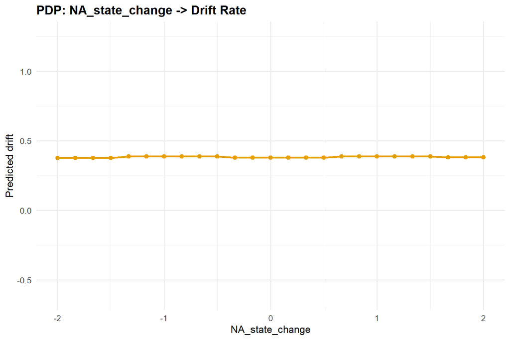

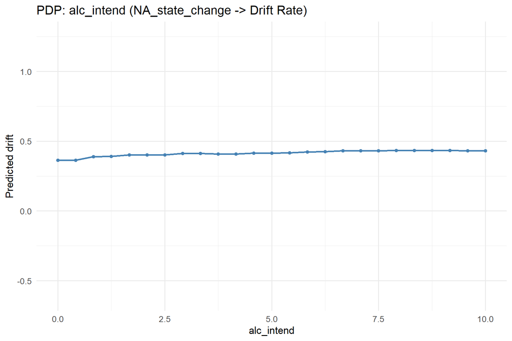

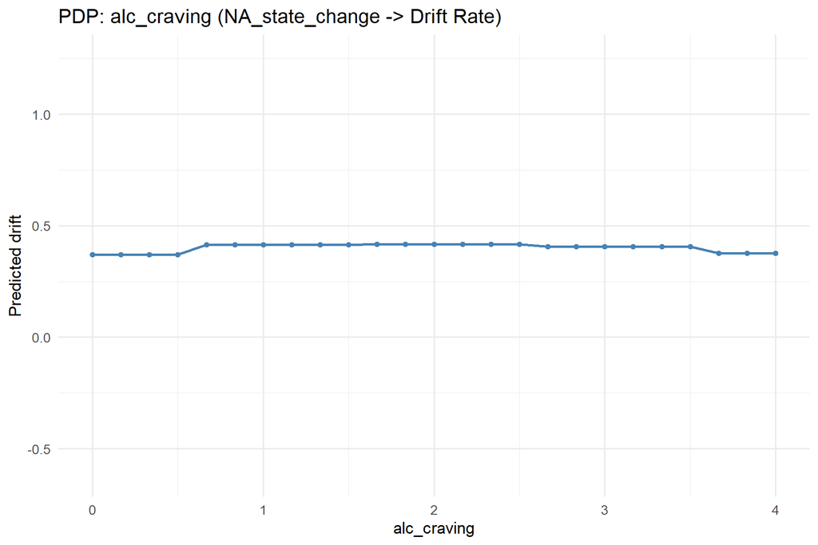

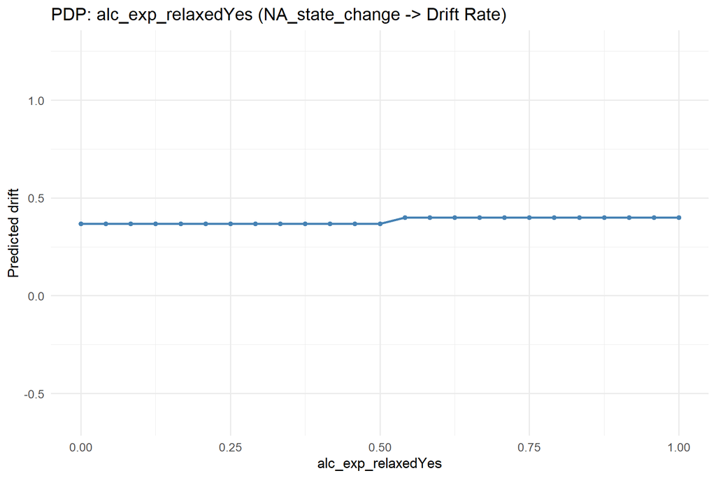

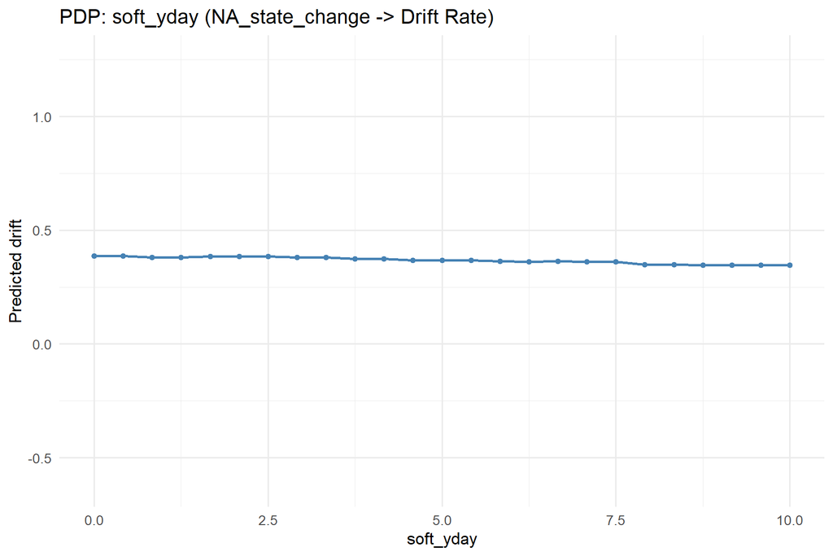

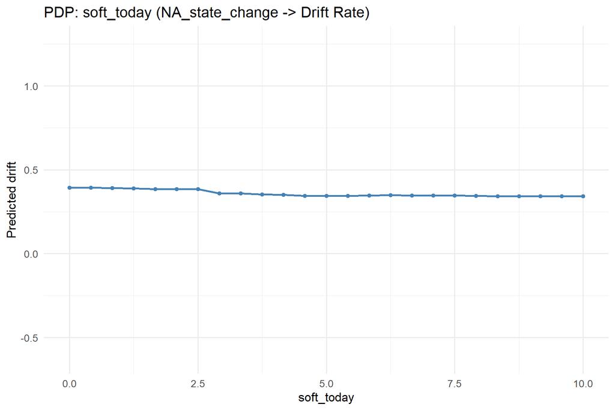

### 6.3.4 Predicted vs. Observed

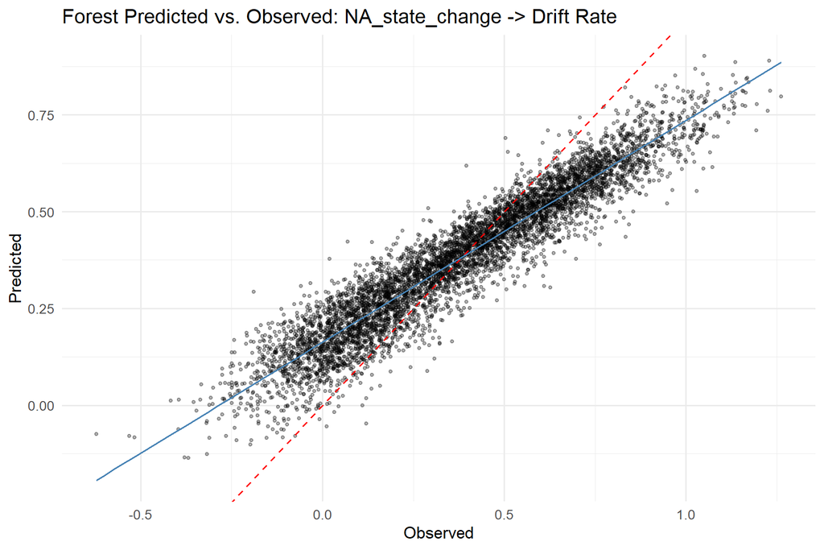

## 6.4 Model Comparison

### 6.4.1 RMSE Comparison (all methods and feature sets)

| Method | Raw | PCA | UMAP |
| --- | --- | --- | --- |
| glmm | 0.3114 | 0.3083 | 0.3132 |
| forest | 0.2564 | 0.2858 | 0.2729 |
| tree | 0.3016 | 0.3021 | 0.3044 |

# 7 Perceived Positive Affect Change (vs. last assessment) (PA_state_change)

## 7.1 Dimensionality Reduction

- **PCA components (80% variance, max 5):** 5
- **UMAP components (matching PCA):** 5

### 7.1.1 PCA Component Composition (top 5 correlated variables)

**PC_1**

| Variable | Correlation |
| --- | --- |
| alc_exp_energeticYes | -0.576 |
| alc_exp_better_moodYes | -0.557 |
| alc_exp_sociableYes | -0.547 |
| alc_exp_buzzYes | -0.502 |
| alc_craving | -0.487 |

**PC_2**

| Variable | Correlation |
| --- | --- |
| alc_exp_injuryYes | -0.595 |
| alc_exp_be_rudeYes | -0.593 |
| alc_exp_embarrassedYes | -0.578 |
| alc_exp_nauseous_vomitYes | -0.491 |
| alc_exp_hangoverYes | -0.468 |

**PC_3**

| Variable | Correlation |
| --- | --- |
| locationschool_work | 0.590 |
| alc_today | -0.578 |
| alc_cuenone | 0.568 |
| time_of_dayevening | -0.476 |
| locationhome | -0.457 |

**PC_4**

| Variable | Correlation |
| --- | --- |
| soft_yday | 0.699 |
| soft_today | 0.650 |
| soft_intend | 0.633 |
| soft_craving | 0.488 |
| alc_exp_embarrassedYes | -0.389 |

**PC_5**

| Variable | Correlation |
| --- | --- |
| locationhome | -0.633 |
| social_context_aloneYes | -0.560 |
| social_context_friend_roommateYes | 0.500 |
| social_context_strangerYes | 0.417 |
| locationsomeone_elses_home | 0.371 |

### 7.1.2 UMAP Component Composition (top 5 correlated variables)

**UMAP_1**

| Variable | Correlation |
| --- | --- |
| alc_yday | -0.304 |
| alc_intend | -0.259 |
| alc_exp_embarrassedYes | -0.238 |
| alc_exp_be_rudeYes | -0.235 |
| alc_craving | -0.220 |

**UMAP_2**

| Variable | Correlation |
| --- | --- |
| alc_exp_embarrassedYes | -0.223 |
| alc_exp_be_rudeYes | -0.220 |
| alc_yday | 0.213 |
| soft_yday | -0.152 |
| soft_today | -0.134 |

**UMAP_3**

| Variable | Correlation |
| --- | --- |
| alc_yday | -0.487 |
| alc_today | -0.442 |
| alc_cuenone | 0.192 |
| alc_intend | -0.149 |
| time_of_dayevening | -0.144 |

**UMAP_4**

| Variable | Correlation |
| --- | --- |
| soft_yday | 0.841 |
| soft_today | 0.735 |
| soft_intend | 0.621 |
| soft_craving | 0.347 |
| alc_exp_be_rudeYes | 0.206 |

**UMAP_5**

| Variable | Correlation |
| --- | --- |
| alc_exp_injuryYes | 0.510 |
| alc_exp_embarrassedYes | 0.379 |
| alc_exp_be_rudeYes | 0.376 |
| alc_exp_nauseous_vomitYes | 0.353 |
| alc_exp_energeticYes | 0.236 |

## 7.2 GLMM Results

### 7.2.1 Raw Features

- **Optimal lambda:** 0 (index 21 of 21)
- **CV RMSE:** 0.3098

**Non-zero coefficients** (focal predictor terms highlighted):

| Term | Estimate | Category |
| --- | --- | --- |
| (Intercept) | 0.3774 | Intercept |
| PA_state_change | -0.0021 | Focal predictor |
| alc_exp_injuryYes | -0.0479 | Covariate main effect |
| alc_exp_embarrassedYes | -0.0452 | Covariate main effect |
| alc_exp_be_rudeYes | -0.0395 | Covariate main effect |
| alc_exp_nauseous_vomitYes | -0.0319 | Covariate main effect |
| alc_exp_hangoverYes | -0.0280 | Covariate main effect |
| alc_exp_relaxedYes | 0.0221 | Covariate main effect |
| social_context_strangerYes | 0.0161 | Covariate main effect |
| alc_exp_better_moodYes | 0.0151 | Covariate main effect |
| locationother | 0.0144 | Covariate main effect |
| alc_cuenone | -0.0141 | Covariate main effect |
| locationrestaurant_cafe | -0.0117 | Covariate main effect |
| alc_cueindirectly_visible | -0.0115 | Covariate main effect |
| alc_mot_enhanceYes | 0.0104 | Covariate main effect |
| alc_mot_copingYes | 0.0100 | Covariate main effect |
| social_context_coworker_classmateYes | 0.0085 | Covariate main effect |
| alc_exp_buzzYes | 0.0079 | Covariate main effect |
| social_context_familyYes | -0.0072 | Covariate main effect |
| alc_exp_sociableYes | -0.0063 | Covariate main effect |
| soft_intend | -0.0059 | Covariate main effect |
| alc_craving | 0.0058 | Covariate main effect |
| time_of_dayevening | -0.0057 | Covariate main effect |
| social_context_otherYes | 0.0056 | Covariate main effect |
| responsibilityYes | -0.0056 | Covariate main effect |
| alc_intend | 0.0052 | Covariate main effect |
| soft_today | -0.0051 | Covariate main effect |
| social_context_romantic_partnerYes | 0.0050 | Covariate main effect |
| bored_state | 0.0041 | Covariate main effect |
| soft_yday | -0.0036 | Covariate main effect |

[output cut: 67 more lines]

- 1 coefficients penalized to zero.*

#### 7.2.1.1 Predicted vs. Observed

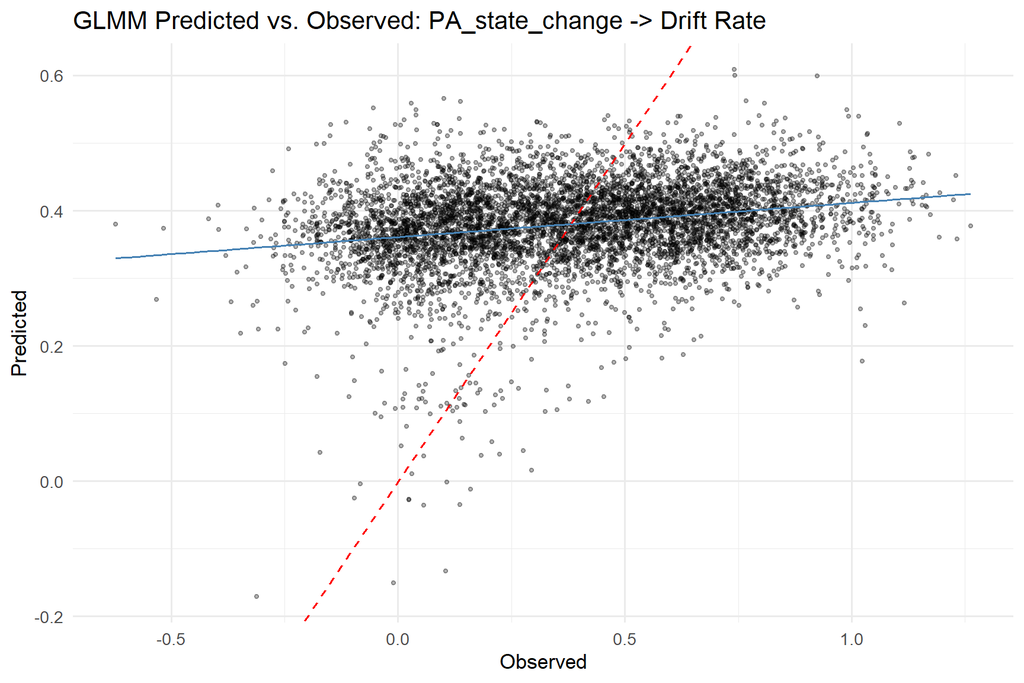

#### 7.2.1.2 Residual Diagnostics

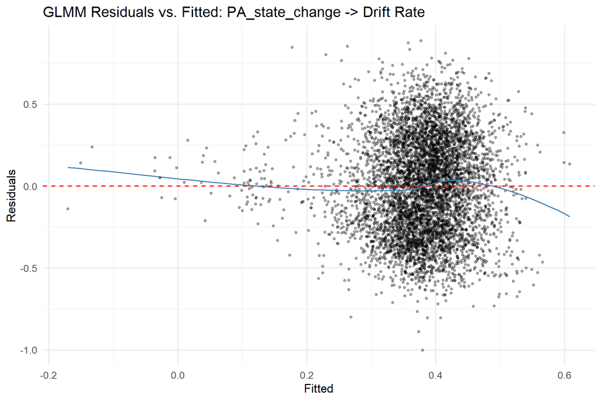

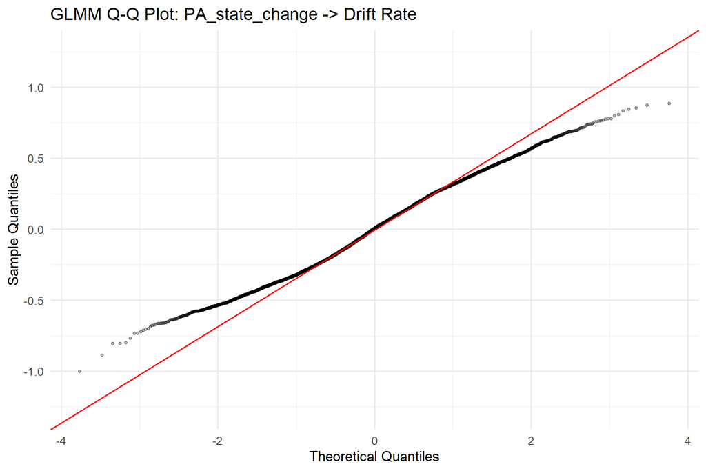

### 7.2.2 PCA Features

- **Optimal lambda:** 100 (index 1 of 21)
- **CV RMSE:** 0.3077

**Non-zero coefficients:**

| Term | Estimate |
| --- | --- |
| (Intercept) | 0.3816 |
| PC_2 | 0.0400 |
| PC_5:PA_state_change | -0.0062 |

- 9 coefficients penalized to zero.*

### 7.2.3 UMAP Features

- **Optimal lambda:** 95 (index 2 of 21)
- **CV RMSE:** 0.3142

**Non-zero coefficients:**

| Term | Estimate |
| --- | --- |
| (Intercept) | 0.3809 |
| UMAP_3 | -0.0082 |
| UMAP_4 | -0.0159 |
| UMAP_1:PA_state_change | -0.0033 |
| UMAP_3:PA_state_change | -0.0005 |
| UMAP_5:PA_state_change | -0.0074 |

- 6 coefficients penalized to zero.*

## 7.3 Random Forest Results (Raw)

### 7.3.1 Tuning Summary

- **mtry:** 22
- **min.node.size:** 5
- **sample.fraction:** 0.756
- **CV RMSE:** 0.2566

### 7.3.2 Variable Importance (Permutation)

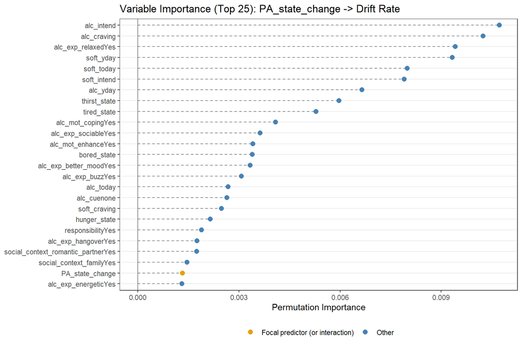

**Full importance ranking:**

| Variable | Importance |
| --- | --- |
| alc_intend | 0.010726 |
| alc_craving | 0.010242 |
| alc_exp_relaxedYes | 0.009421 |
| soft_yday | 0.009329 |
| soft_today | 0.007995 |
| soft_intend | 0.007907 |
| alc_yday | 0.006646 |
| thirst_state | 0.005971 |
| tired_state | 0.005283 |
| alc_mot_copingYes | 0.004088 |
| alc_exp_sociableYes | 0.003630 |
| alc_mot_enhanceYes | 0.003409 |
| bored_state | 0.003398 |
| alc_exp_better_moodYes | 0.003336 |
| alc_exp_buzzYes | 0.003072 |
| alc_today | 0.002677 |
| alc_cuenone | 0.002644 |
| soft_craving | 0.002483 |
| hunger_state | 0.002146 |
| responsibilityYes | 0.001886 |
| alc_exp_hangoverYes | 0.001755 |
| social_context_romantic_partnerYes | 0.001744 |
| social_context_familyYes | 0.001464 |
| PA_state_change | 0.001325 |
| alc_exp_energeticYes | 0.001305 |
| alc_exp_embarrassedYes | 0.001070 |
| social_context_aloneYes | 0.001013 |
| time_of_dayevening | 0.000866 |
| alc_exp_be_rudeYes | 0.000783 |
| locationhome | 0.000705 |
| alc_mot_socialYes | 0.000666 |
| locationschool_work | 0.000572 |
| alc_exp_nauseous_vomitYes | 0.000413 |
| locationother | 0.000372 |
| alc_cueindirectly_visible | 0.000257 |
| social_context_strangerYes | 0.000213 |
| social_context_coworker_classmateYes | 0.000207 |
| social_context_friend_roommateYes | 0.000200 |
| alc_exp_injuryYes | 0.000172 |
| day_of_weekSun | 0.000107 |
| locationsomeone_elses_home | 0.000065 |
| locationoutdoors | 0.000054 |
| social_context_otherYes | 0.000010 |
| locationrestaurant_cafe | 0.000007 |
| day_of_weekWed | -0.000040 |
| day_of_weekSat | -0.000056 |
| day_of_weekMon | -0.000058 |
| day_of_weekThu | -0.000172 |
| day_of_weekTue | -0.000181 |

### 7.3.3 Partial Dependence Plots

PDP for the focal predictor and the top 5 most important non-interaction covariates.

#### 7.3.3.1 Focal Predictor: PA_state_change

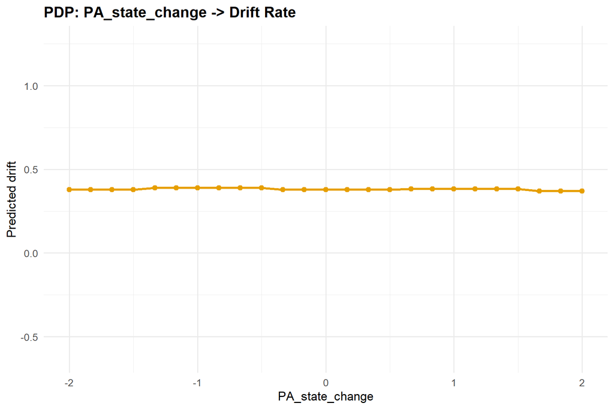

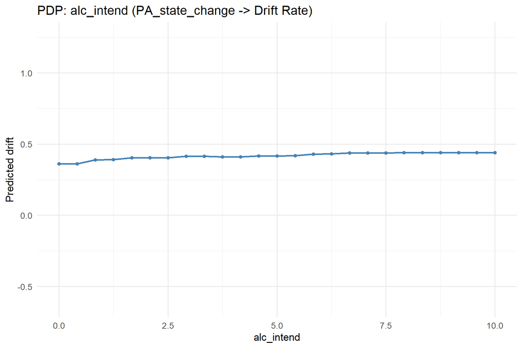

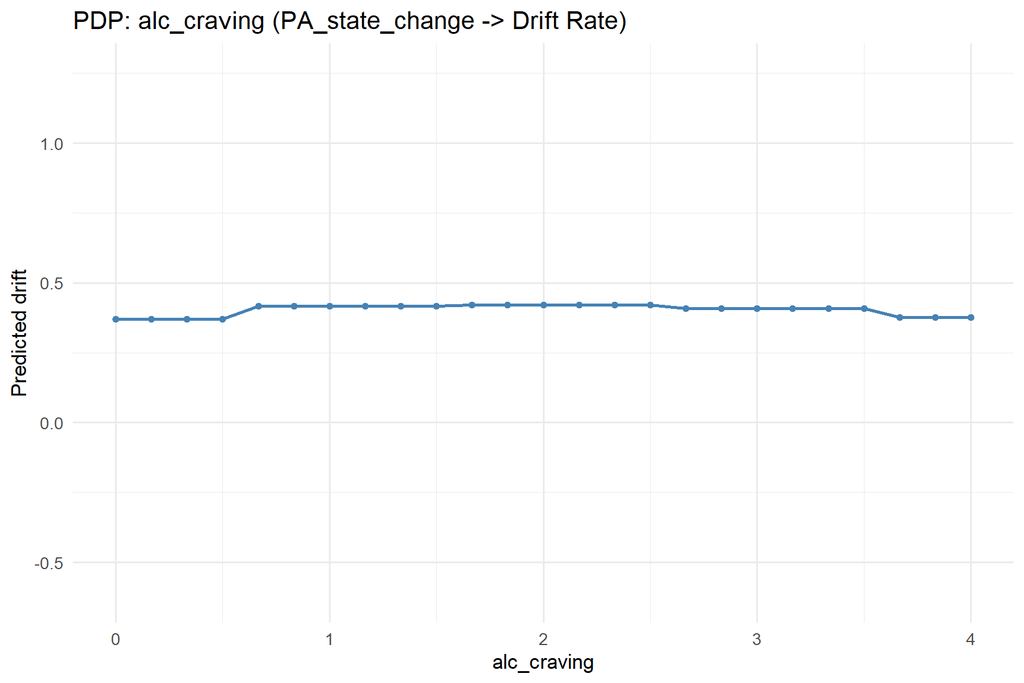

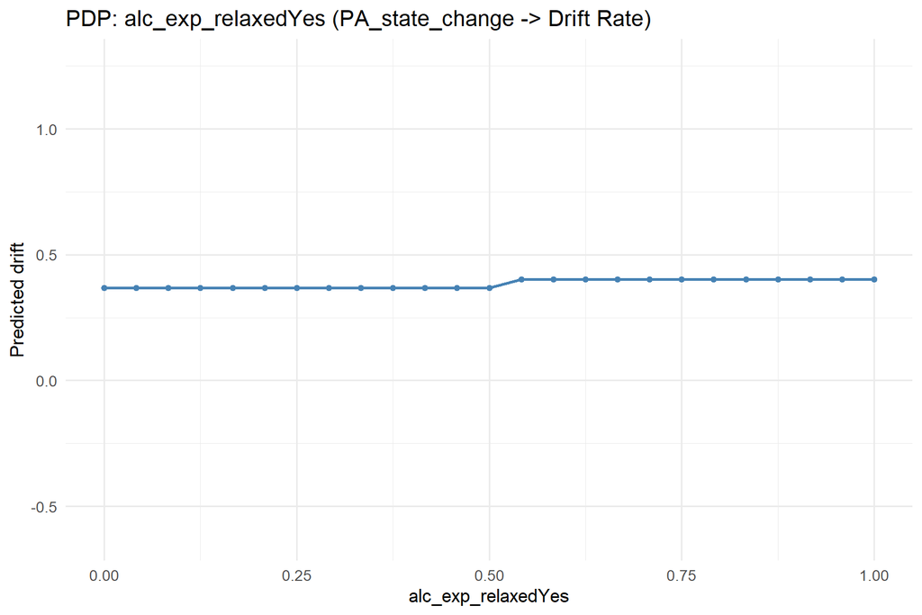

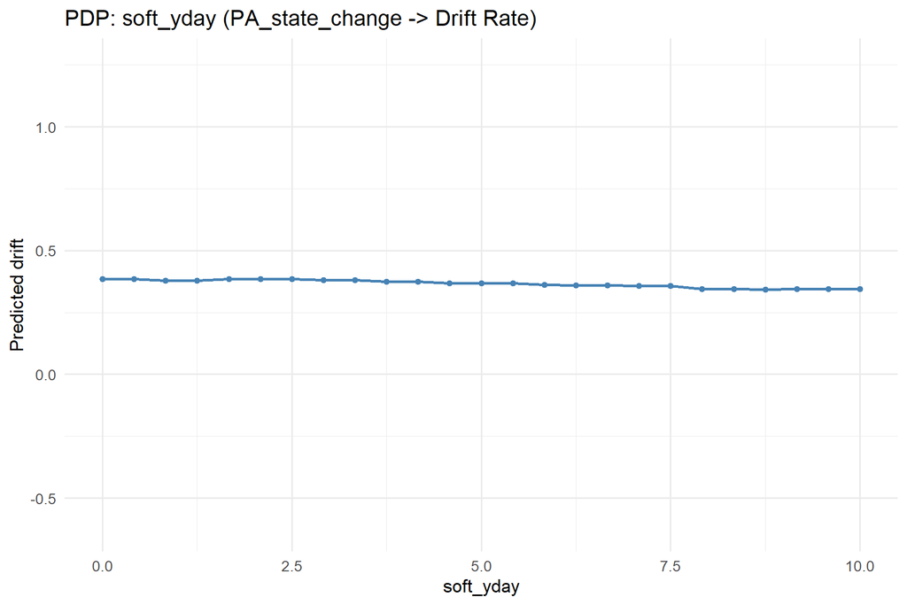

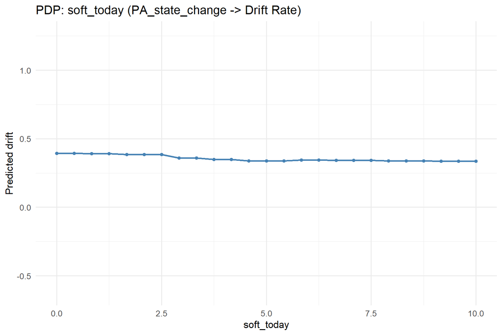

### 7.3.4 Predicted vs. Observed

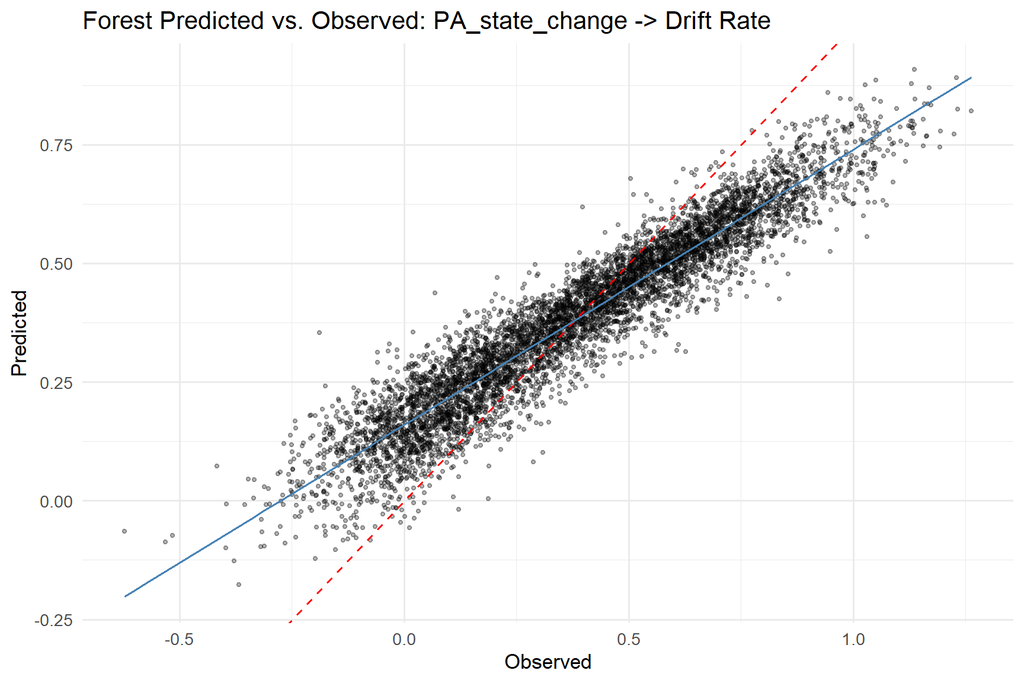

## 7.4 Model Comparison

### 7.4.1 RMSE Comparison (all methods and feature sets)

| Method | Raw | PCA | UMAP |
| --- | --- | --- | --- |
| glmm | 0.3098 | 0.3077 | 0.3142 |
| forest | 0.2566 | 0.2858 | 0.2714 |
| tree | 0.3016 | 0.3019 | 0.3037 |